# STATS 326/786

Week 7 Tutorial

# Problem 1

Consider the number of pigs slaughtered in Victoria, available in the `aus_livestock` data set. This is plotted below.

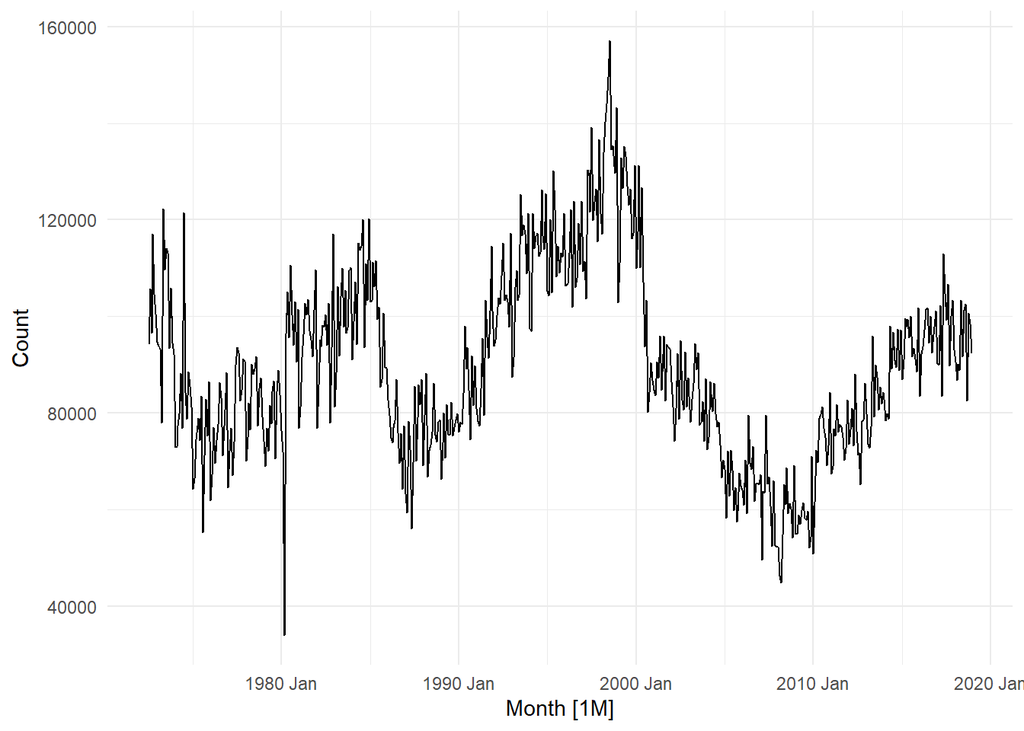

> Fit three different simple exponential smoothing (`ETS(A,N,N)`) models. One with $\alpha = 0.001$, one with $\alpha = 0.999$ and one with $\alpha$ that is automatically optimised. You can specify the value of $\alpha$ in the `trend` function.

Solution:

```r
fit = pigs %>%
  model(a0 = ETS(Count ~ error("A") + trend("N", alpha = 0.001) + season("N")),
        a1 = ETS(Count ~ error("A") + trend("N", alpha = 0.999) + season("N")),
        a.opt = ETS(Count ~ error("A") + trend("N") + season("N")))
```

> For the model where $\alpha$ was automatically optimised, extract and interpret the estimates of $l_0$ and $\alpha$.

Solution:

```r
fit %>%
  select(a.opt) %>%
  report()
```

```
## Series: Count
## Model: ETS(A,N,N)
##   Smoothing parameters:
##     alpha = 0.3221247
##
##   Initial states:
##      l[0]
##  100646.6
##
##   sigma^2:  87480760
##
##      AIC     AICc      BIC
## 13737.10 13737.14 13750.07
```

$l_0$ is the fitted value at time $t = 1$ (i.e., the initial level). We estimate this to be $\hat{l}_0 = 100647$. $\alpha$ is the smoothing parameter of the level of the time series. We estimate this to be $\hat{\alpha} = 0.322$. This means that we have moderate amount of smoothing of the level, and that rather than weighting heavily on the most recent observation (as would be done with the naive forecast method), there is a slow(ish) exponential decay in weights applied to past observations.

> On three seperate plots overlay the fitted values on the original time series. Comment on what you observe.

Solution:

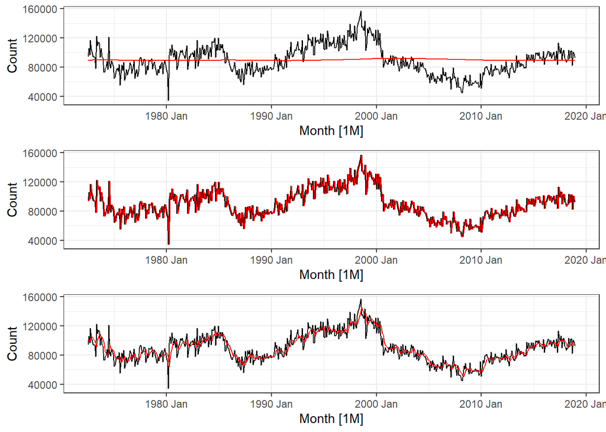

```r
# Extract fitted values
fit.augment = augment(fit) %>% select(.fitted)

# alpha = 0.001
p1 = pigs %>%
  autoplot(Count) +
  autolayer(fit.augment %>% filter(.model == "a0"),
            .fitted, colour = "red") +
  theme_bw()

# alpha = 0.999
p2 = pigs %>%
  autoplot(Count) +
  autolayer(fit.augment %>% filter(.model == "a1"),
            .fitted, colour = "red") +
  theme_bw()

# alpha = optim
p3 = pigs %>%
  autoplot(Count) +
  autolayer(fit.augment %>% filter(.model == "a.opt"),
            .fitted, colour = "red") +
  theme_bw()

# Plot
grid.arrange(p1, p2, p3, nrow = 3)
```

```r
# Note need grid and gridExtra to use grid.arrange
# Can just plot individually instead
```

The ETS(A,N,N) model with $\alpha = 0.001$ has very smooth and nearly flat fitted values, centered around the average of the time series. This looks very similar to the average forecast method. The ETS(A,N,N) model with $\alpha = 0.999$ has fitted values that are not smooth and appear to be close to the most recent observation. This looks very similar to the naive forecast method. The ETS(A,N,N) model with $\alpha = 0.322$ has an in-between amount of smoothing.

> Using the `weight.plot` function provided below, plot the weights that the past 20 observations contribute to the exponenentially smoothed value at the current time point. Comment on what you observe.

Solution:

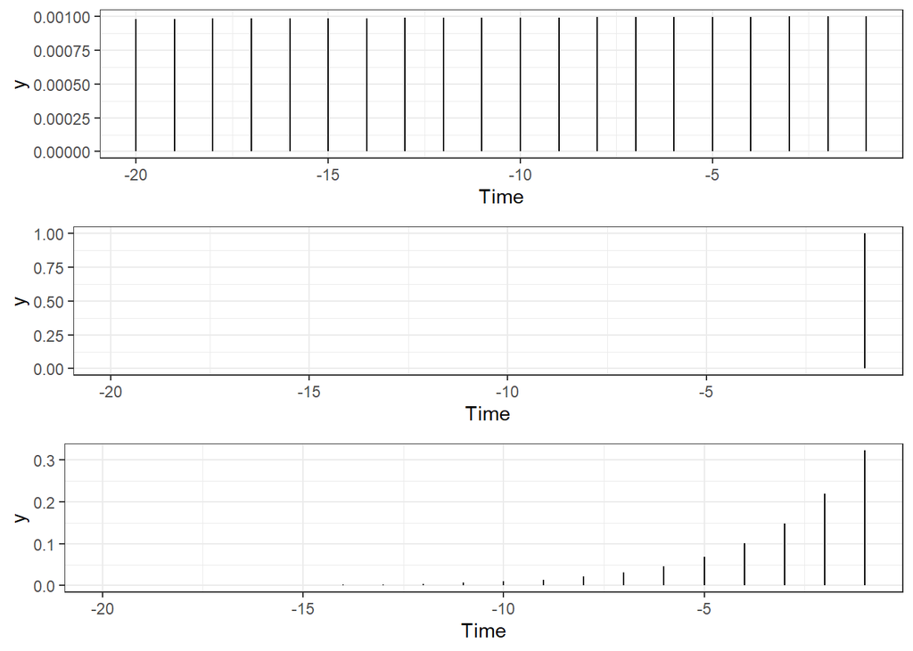

```r
# Function to use
weight.plot = function(alpha, N = 20) {

  # alpha is the smoothing parameter for the level
  # N is the number of time points in the past to plot

  Weight = alpha    # First weight
  for (i in 2:N) {  # Other weights
    Weight[i] = Weight[i - 1] * (1 - alpha)
  }

  # Create tsibble
  data <- as_tsibble(data.frame(Time = (-(1:N)),
                      Weight = Weight),
           index = Time)

  # Plot
  ggplot(data = data, mapping = aes(x = Time, y = Weight)) +
    geom_segment(aes(x = Time, xend = Time,
                     y = 0, yend = Weight)) +
    theme_bw()

}

# Plots
p1 = weight.plot(0.001)
p2 = weight.plot(0.999)
p3 = weight.plot(0.322)
grid.arrange(p1, p2, p3, nrow = 3)
```

The ETS(A,N,N) model with $\alpha = 0.001$ has a near equal amount of weight placed on on all past time points, nearly consistent with the average forecast method (which would have equal weight on all time points). The ETS(A,N,N) model with $\alpha = 0.999$ has pretty much all of the weight on $t - 1$ (with very minor amount of weight on previous time points), nearly consistent with the naive forecast method. The ETS(A,N,N) model with $\alpha = 0.322$ has an in-between amount of smoothing, where we can see exponential decay of weights, i.e., $y_t$ depends on $y_{t-1}$ by 0.322, $y_{t-2}$ by $0.322\times(1-0.322) = 0.218$, etc. Hence, exponential smoothing.

Solution:

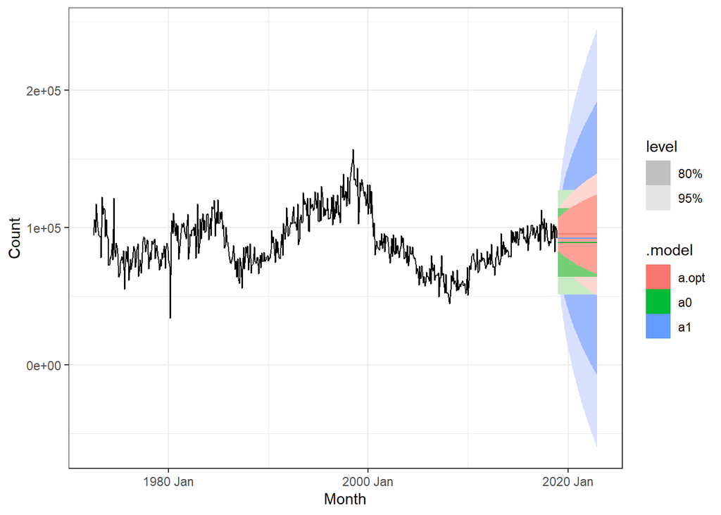

```r
fc = fit %>%
  forecast(h = 48)

fc %>%
  autoplot(pigs) +
  theme_bw()
```

# Extra: Problem 2

Consider the Algerian exports time series in the `global_economy` data set. This is plotted below. An ETS(A,N,N) model is fitted to it and the optimal parameters are reported.

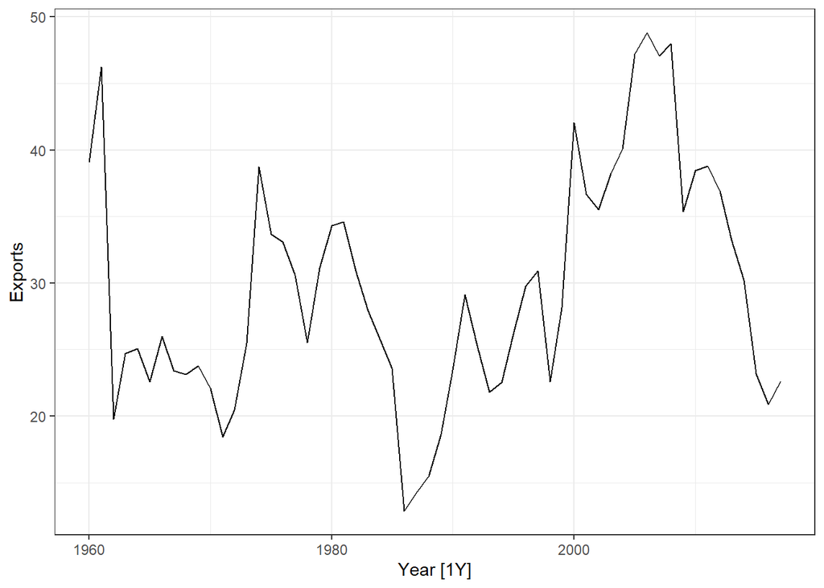

```r
algeria_economy <- global_economy %>%
  filter(Country == "Algeria")

algeria_economy %>%
  autoplot(Exports) +
  theme_bw()
```

```r
fit <- algeria_economy %>%
  model(ETS(Exports ~ error("A") + trend("N") + season("N")))
report(fit)  # Extract parameters
```

```
## Series: Exports
## Model: ETS(A,N,N)
##   Smoothing parameters:
##     alpha = 0.8399875
##
##   Initial states:
##    l[0]
##  39.539
##
##   sigma^2:  35.6301
##
##      AIC     AICc      BIC
## 446.7154 447.1599 452.8968
```

> Write your own function to implement simple exponential smoothing. The function should take arguments `y` (the time series), `alpha` (the smoothing parameter, $\alpha$) and `level` (the initial level, $l_0$). It should return the fitted values of the exponentially smoothed time series. Check to see that this function produces the same fitted values as `ETS()`.

> Modify your function from the previous exercise to return the sum of squared errors rather than the fitted values. Then use the `optim` function to find the optimal values of $\alpha$ and $l_0$. Do you get the same values as the `ETS()` function?

```r
# Function for simple exponential smoothing
SES = function(y, alpha, level) {
  n = length(y)
  yhat = rep(NA, n)
  yhat[1] = level
  yhat[2] = alpha * y[1] + (1 - alpha) * level
  for (i in 3:n) {
    yhat[i] = alpha * y[i - 1] + (1 - alpha) * yhat[i - 1]  # Recursive formula
  }
  return(yhat)
}

# Extract fitted values from SES function
SES(algeria_economy %>% pull(Exports), 0.8399875, 39.539)
```

```
##  [1] 39.53900 39.12251 45.10494 23.84396 24.55016 24.99863 22.98712 25.50631
##  [9] 23.76595 23.23649 23.70040 22.33318 19.06507 20.22803 24.65950 36.49454
## [17] 34.13787 33.22792 31.00922 26.41165 30.39038 33.70672 34.44635 31.48834
## [25] 28.50930 26.15794 23.99581 14.63746 14.33088 15.31953 18.10807 22.58992
## [33] 28.07328 25.76022 22.42014 22.51303 25.60565 29.09563 30.61658 23.86457
## [41] 27.46438 39.73268 37.17628 35.77203 37.85251 39.70108 46.00444 48.36165
## [49] 47.27514 47.86162 37.37020 38.27264 38.70466 37.18083 33.84530 30.79935
## [57] 24.39229 21.42522
```

```r
# Extract fitted values from ETS fit
augment(fit) %>% pull(.fitted)  # Same fitted values
```

```
##  [1] 39.53900 39.12251 45.10494 23.84396 24.55016 24.99863 22.98712 25.50631
##  [9] 23.76595 23.23649 23.70040 22.33318 19.06507 20.22803 24.65950 36.49454
## [17] 34.13787 33.22792 31.00922 26.41165 30.39038 33.70672 34.44635 31.48834
## [25] 28.50930 26.15794 23.99581 14.63746 14.33088 15.31953 18.10807 22.58992
## [33] 28.07328 25.76022 22.42014 22.51303 25.60565 29.09563 30.61658 23.86457
## [41] 27.46438 39.73268 37.17628 35.77203 37.85251 39.70108 46.00444 48.36165
## [49] 47.27514 47.86162 37.37020 38.27264 38.70466 37.18083 33.84530 30.79935
## [57] 24.39229 21.42522
```

```r
# Sum of squared errors to minimise
SSE = function(y, pars) {
  n = length(y)
  alpha = pars[1]
  level = pars[2]
  yhat = c()
  yhat[1] = level
  yhat[2] = alpha * y[1] + (1 - alpha) * level
  for (i in 3:n) {
    yhat[i] = alpha * y[i - 1] + (1 - alpha) * yhat[i - 1]
  }
  return(sum((y - yhat) ^ 2))
}

SSE(algeria_economy %>% pull(Exports), c(0.8399875, 39.539))
```

```
## [1] 1995.285
```

```r
optim(c(0, 0), SSE, y = algeria_economy %>% pull(Exports))
```

```
## $par
## [1]  0.8395618 39.5529007
##
## $value
## [1] 1995.285
##
## $counts
## function gradient
##       83       NA
##
## $convergence
## [1] 0
##
## $message
## NULL
```

We get the same fitted values when inputting the optimum parameters from ETS into our own SES function.

When performing our own optimisation, our estimates are pretty close to what is produced by the ETS function. There may be discrepancies depending on the optimisation method and starting values.